# Shipra_Gupta_Final_Project

## Investigate the same analysis in all countries except US

```python
# Subset Other country dataset
other_countries_df = df.loc[df['Native-country'] != 'United-States']
other_countries_df.head()
```

|  | Age | Workclass | Fnlwgt | Education | Education-num | Marital-status | Occupation | Relationship | Race | Sex | Capital-gain | Capital-loss | Hours-per-week | Native-country | Income |
| --- | --- | --- | --- | --- | --- | --- | --- | --- | --- | --- | --- | --- | --- | --- | --- |
| 4 | 28 | Private | 338409 | Bachelors | 13 | Married-civ-spouse | Prof-specialty | Wife | Black | Female | 0 | 0 | 40 | Cuba | <=50K |
| 6 | 49 | Private | 160187 | 9th | 5 | Married-spouse-absent | Other-service | Not-in-family | Black | Female | 0 | 0 | 16 | Jamaica | <=50K |
| 11 | 30 | State-gov | 141297 | Bachelors | 13 | Married-civ-spouse | Prof-specialty | Husband | Asian-Pac-Islander | Male | 0 | 0 | 40 | India | >50K |
| 14 | 40 | Private | 121772 | Assoc-voc | 11 | Married-civ-spouse | Craft-repair | Husband | Asian-Pac-Islander | Male | 0 | 0 | 40 | Unknown | >50K |
| 15 | 34 | Private | 245487 | 7th-8th | 4 | Married-civ-spouse | Transport-moving | Husband | Amer-Indian-Eskimo | Male | 0 | 0 | 45 | Mexico | <=50K |

```python
# Distribution of all other countries
other_countries_df['Native-country'].value_counts()
```

```
Native-country
Mexico                        643
Unknown                       583
Philippines                   198
Germany                       137
Canada                        121
Puerto-Rico                   114
El-Salvador                   106
India                         100
Cuba                           95
England                        90
Jamaica                        81
South                          80
China                          75
Italy                          73
Dominican-Republic             70
Vietnam                        67
Guatemala                      64
Japan                          62
Poland                         60
Columbia                       59
Taiwan                         51
Haiti                          44
Iran                           43
Portugal                       37
Nicaragua                      34
Peru                           31
France                         29
Greece                         29
Ecuador                        28
Ireland                        24
Hong                           20
Cambodia                       19
Trinadad&Tobago                19
Laos                           18
Thailand                       18
Yugoslavia                     16
Outlying-US(Guam-USVI-etc)     14
Honduras                       13
Hungary                        13
Scotland                       12
Holand-Netherlands              1
Name: count, dtype: int64
```

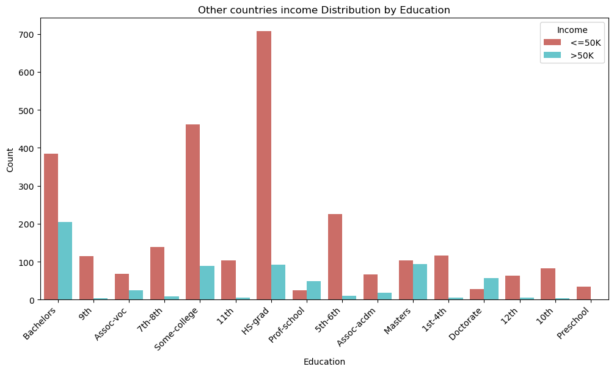

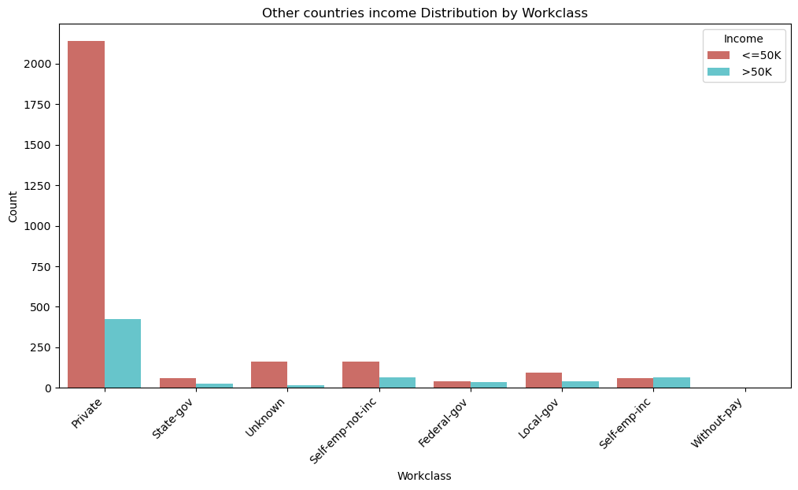

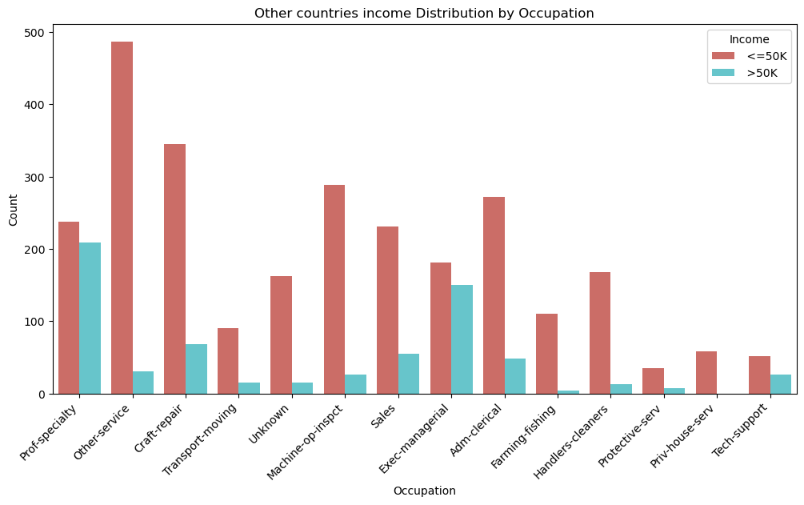

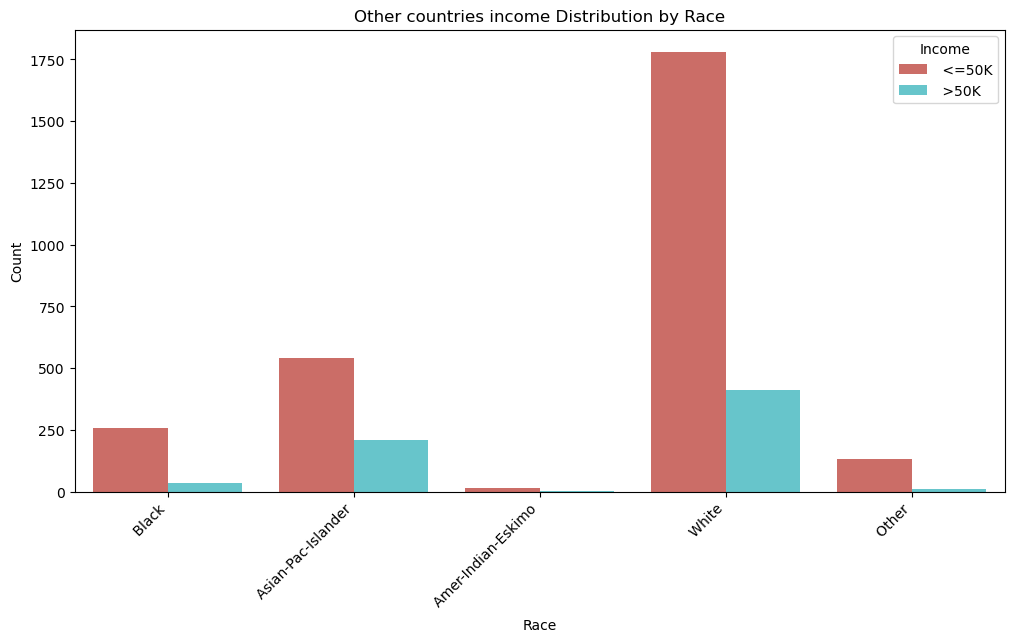

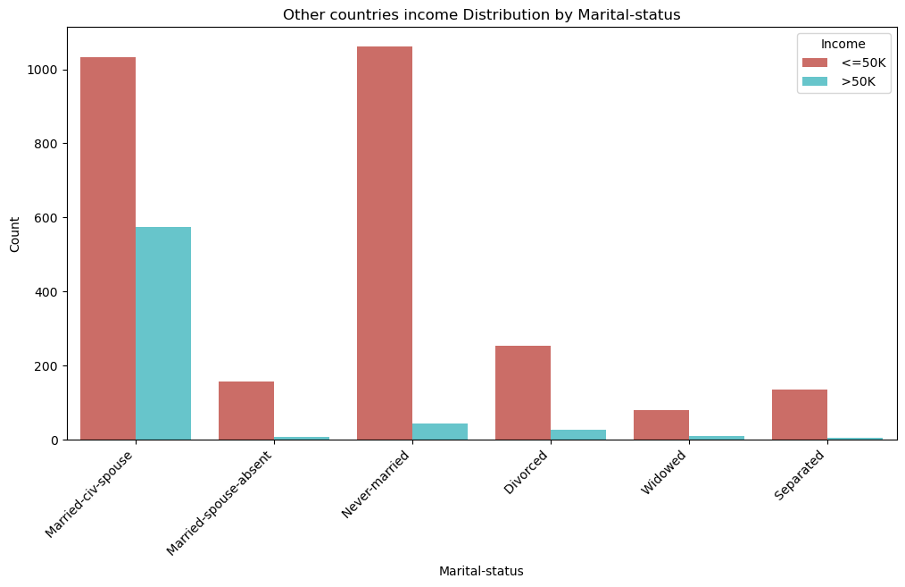

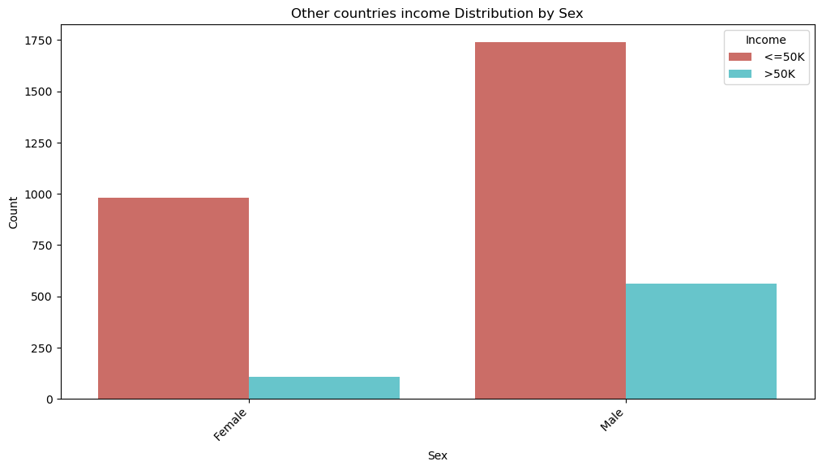

```python
# Analyze the impact of individual features on income using grouped bar plots in countries except US
features_of_interest = ['Education', 'Workclass', 'Occupation', 'Race', 'Marital-status', 'Sex']

for feature in features_of_interest:
    plt.figure(figsize=(12, 6))
    sns.countplot(x=feature, hue='Income', data=other_countries_df, palette='hls')
    plt.title(f'Other countries income Distribution by {feature}')
    plt.xlabel(feature)
    plt.ylabel('Count')
    plt.xticks(rotation=45, ha='right')
    plt.show()
```

Other countries Based on education, this plot tells us that people who earned high school graduate, some college, bachelor’s degrees and school 5-6th 7-8th class education are coming into the picture with salary of <=50k.

Income distribution by Workclass People who worked in the private sector have the highest regardless of earning <=50k or >50k.

Race White race represents the highest income with <=50k and >50k followed by Asian-Pac-Islander group.

Income distribution by Marital status Never Married and Married-civ-spouse are both showing high trends with <=50k income.

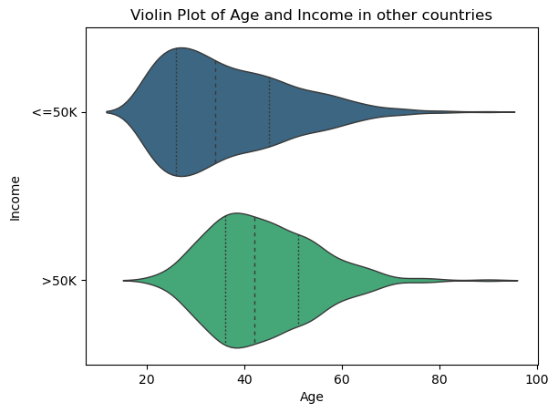

```python
# Create a violin plot using seaborn to visualize Age vs income pattern
sns.violinplot(x='Age', y='Income', data=other_countries_df, palette='viridis', inner="quart", linewidth=1)

# Set plot labels and title
plt.xlabel('Age')
plt.ylabel('Income')
plt.title('Violin Plot of Age and Income in other countries')

# Show the plot
plt.show()
```